# Automated Prediction of Athletic Exercise Quality based on readings from Movement Sensors

Katarzyna Bojarska

2018 11 13

## Executive Summary

The aim of the project is to compare the goodness of predictions of the manner in which 6 athletes did the Unilateral Dumbbell Biceps Curl, based on the readings from either four or from a single movement sensor, depending on its location (on the belt, forearm, arm, or dumbell).  
The athletes were asked to perform one set of 10 repetitions of the exercise in five different ways: exactly according to the specification or making one of 4 common mistakes (5 classes of exercise quality, A, B, C, D and E, where A refers to the correct way of performing the Biceps Curl).  
The original study involved prediction from all the sensors and provided highly accurate predictions (of over 99.5%).  
We now want to focus on the accuracy of predictions from single movement sensors.  
More information about the original study is available from the website here: http://web.archive.org/web/20161224072740/http:/groupware.les.inf.puc-rio.br/har (see the section on the Weight Lifting Exercise Dataset).

## Preparation of the dataset

```r
#load the libraries
library(caret); library(dplyr); library(randomForest); library(doParallel); library(ggplot2)
#load the training and testing data
if(!file.exists("./pml-training.csv")) {
    fileUrl1 <- "https://d396qusza40orc.cloudfront.net/predmachlearn/pml-training.csv"
    download.file(fileUrl1, destfile = "./pml-training.csv")}
#name the training and testing datasets
training = read.csv("pml-training.csv")
#display the properties of the dataset
names(training)
```

```
##   [1] "X"                        "user_name"
##   [3] "raw_timestamp_part_1"     "raw_timestamp_part_2"
##   [5] "cvtd_timestamp"           "new_window"
##   [7] "num_window"               "roll_belt"
##   [9] "pitch_belt"               "yaw_belt"
##  [11] "total_accel_belt"         "kurtosis_roll_belt"
##  [13] "kurtosis_picth_belt"      "kurtosis_yaw_belt"
##  [15] "skewness_roll_belt"       "skewness_roll_belt.1"
##  [17] "skewness_yaw_belt"        "max_roll_belt"
##  [19] "max_picth_belt"           "max_yaw_belt"
##  [21] "min_roll_belt"            "min_pitch_belt"
##  [23] "min_yaw_belt"             "amplitude_roll_belt"
##  [25] "amplitude_pitch_belt"     "amplitude_yaw_belt"
##  [27] "var_total_accel_belt"     "avg_roll_belt"
##  [29] "stddev_roll_belt"         "var_roll_belt"
```

[output cut: 65 more lines]

The initial dataset consisted of 19622 observations of 160 variables. Beside index, user identification and time related data specific for individual users, the dataset contained three-dimensional raw data from accelerometer, gyroscope and magnetometer - sensors mounted in the users’ glove, armband, lumbar belt and dumbbell. The researchers calculated also eight features: mean, variance, standard deviation, max, min, amplitude, kurtosis and skewness for the Euler angles of each of the four sensors, generating in total 96 derived feature sets. Most of the derived variables were later excluded from the analysis because of large amount of missing data. The dependent variable was the manner in which the athletes performed the exercise: exactly according to the specification (Class A), throwing the elbows to the front (Class B), lifting the dumbbell only halfway (Class C), lowering the dumbbell only halfway (Class D) and throwing the hips to the front (Class E).

```r
#identify the number of missing values for each variable
missingi <- data.frame(mis = sapply(training, function(x) sum(is.na(x))))
#calculate the proportion of missing values for each variable
missingi$procmis <- round(missingi$mis/nrow(training),3)
#display all levels of proportions of missing values
table(missingi$procmis)
```

```
##
##     0 0.979
##    93    67
```

```r
#exclude variables with high amount of missing values from the dataset
training <- training[,missingi$mis==0]
#identify variables with near zero variance
nzv_an <- nearZeroVar(training,saveMetrics = T)
#exclude variables with near zero variance
training <- training[,nzv_an$nzv=="FALSE"]
new <- training[,-c(1:6)]
#split the dataset for training and testing
inTrain <- createDataPartition(y=new$classe,p=0.8, list=FALSE)
train <- new[inTrain,];
test <- new[-inTrain,]
```

93 variables contained no missing values, while the remaining 67 variables contained each exactly 19216 missing values out of 19622 observations (97.9%). The latter were excluded from the dataset. The next step was to exclude variables with near zero variance. Finally, we excluded several user specific variables that wouldn’t be suitable for prediction, such as names of the participants, row numbers and time stamps. The final dataset contained 53 variables, including one categorical, 5-level dependent variable, “classe”, and 52 potential predictors, of which 25 were integer and 27 were numeric.. It was then split into a training and testing subset, consisting of 15699 and 3923 observations, reslectively.

```r
#display frequencies for the levels of dependent variable in the train dataset
table(train$classe)
```

```
##
##    A    B    C    D    E
## 4464 3038 2738 2573 2886
```

Next we prepared 4 separate datasets for each movement sensor. Each dataset contained the dependent variable and a set of predictors associated with only one sensor.

```r
forearm <- grepl("forearm",names(new))
forearm_train <- cbind(train[,forearm],classe = train$classe)
forearm_test <- cbind(test[,forearm],classe = test$classe)

arm <- grepl("_arm",names(new))
arm_train <- cbind(train[,arm],classe = train$classe)
arm_test <- cbind(test[,arm],classe = test$classe)

belt <- grepl("belt",names(new))
belt_train <- cbind(train[,belt],classe = train$classe)
belt_test <- cbind(test[,belt],classe = test$classe)

dumbbell <- grepl("dumbbell",names(new))
dumbbell_train <- cbind(train[,dumbbell],classe = train$classe)
dumbbell_test <- cbind(test[,dumbbell],classe = test$classe)
```

## Full model fitting and testing

Our first choice to predict categorical dependent variable by numeric predictors was the random forest classification method. Random forest is an extension of bagging on classification/regression trees. It involves repeated bootstraping samples, testing various splits of classification trees and voting final model. This method doesn’t require data normalization or log transformations and performs internal validation to assess OOB error. First, we run the procedure on the entire dataset containing readings from all four sensors.

```r
#enable parallel processing
cl <- makePSOCKcluster(5)
registerDoParallel(cl)
#fit the random forest model on the training dataset
rf<-randomForest(train$classe ~ ., data=train, prox=TRUE, ntree=500)
rf
```

```
##
## Call:
##  randomForest(formula = train$classe ~ ., data = train, prox = TRUE,      ntree = 500)
##                Type of random forest: classification
##                      Number of trees: 500
## No. of variables tried at each split: 7
##
##         OOB estimate of  error rate: 0.46%
## Confusion matrix:
##      A    B    C    D    E  class.error
## A 4462    2    0    0    0 0.0004480287
## B   15 3018    5    0    0 0.0065832785
## C    0   14 2722    2    0 0.0058436815
## D    0    0   26 2545    2 0.0108822386
## E    0    0    1    6 2879 0.0024255024
```

The procedure was capable of correctly classifying around 99.5% of the observations from the dataset. The estimated rate of OOB error was below 0.5%.  
The importance of the predictor variables is listed and plotted below.

```r
#display the variable importance
vimp <- as.data.frame(varImp(rf))
vimp <- data.frame(names   = rownames(vimp),overall = vimp$Overall)
vimp <- vimp[order(vimp$overall,decreasing = T),]
vimp
```

```
##                   names   overall
## 1             roll_belt 985.33550
## 3              yaw_belt 705.56716
## 41        pitch_forearm 647.57395
## 39    magnet_dumbbell_z 605.19636
## 2            pitch_belt 561.58935
## 38    magnet_dumbbell_y 530.89835
## 40         roll_forearm 498.01108
## 37    magnet_dumbbell_x 393.23693
## 27        roll_dumbbell 338.48625
## 10         accel_belt_z 319.62155
## 13        magnet_belt_z 319.04962
## 35     accel_dumbbell_y 311.34382
## 12        magnet_belt_y 301.29291
## 36     accel_dumbbell_z 265.35008
```

[output cut: 38 more lines]

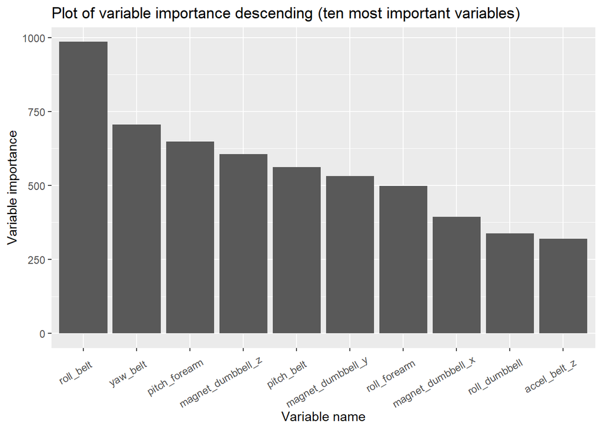

```r
#plot ten most important variables
p <- ggplot(vimp[1:10,], aes(x = reorder(names, -overall), y = overall)) +
         geom_bar(stat = "identity") + theme(axis.text.x=element_text(angle=30,vjust=.8, hjust=0.8)) + ggtitle("Plot of variable importance descending (ten most important variables)") +
  xlab("Variable name") + ylab("Variable importance")
p
```

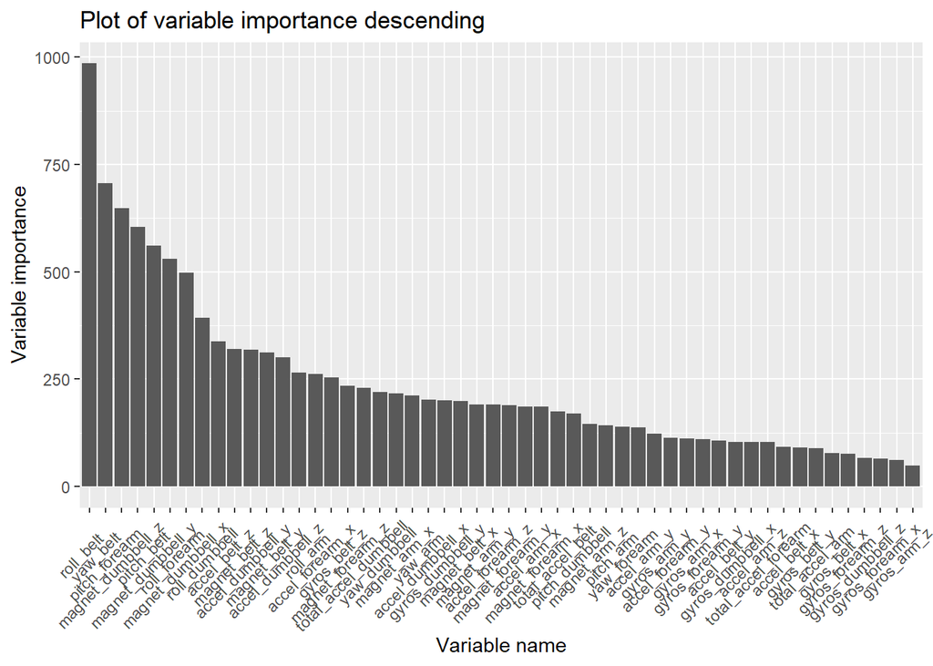

```r
#plot all the variables ordered by importance
p1 <- ggplot(vimp, aes(x = reorder(names, -overall), y = overall)) +
         geom_bar(stat = "identity") + theme(axis.text.x=element_text(angle=45,vjust=.8, hjust=0.8)) + ggtitle("Plot of variable importance descending") +
  xlab("Variable name") + ylab("Variable importance")
p1
```

As we can see, the variables which contributed to the model the most, were mostly readings from belt and dumbbell devices, followed by the sensors attached to the forarm. Sensors mounted on the athlete’s arm were apparently of lesser importance.

## Testing predictions from separate sensors

We then ran the same random forest classification procedure on each of the four separate datasets.

```r
#fit the random forest model on the four training datasets
rf_forearm <-randomForest(forearm_train$classe ~ ., data=forearm_train, prox=TRUE, ntree=500)
rf_forearm
```

```
##
## Call:
##  randomForest(formula = forearm_train$classe ~ ., data = forearm_train,      prox = TRUE, ntree = 500)
##                Type of random forest: classification
##                      Number of trees: 500
## No. of variables tried at each split: 3
##
##         OOB estimate of  error rate: 9.34%
## Confusion matrix:
##      A    B    C    D    E class.error
## A 4327   74   24   22   17  0.03068996
## B  130 2690   96   30   92  0.11454905
## C   37  264 2293   92   52  0.16252739
## D   20   35  165 2270   83  0.11776137
## E   30   86   31   86 2653  0.08073458
```

```r
rf_arm <-randomForest(arm_train$classe ~ ., data=arm_train, prox=TRUE, ntree=500)
rf_arm
```

```
##
## Call:
##  randomForest(formula = arm_train$classe ~ ., data = arm_train,      prox = TRUE, ntree = 500)
##                Type of random forest: classification
##                      Number of trees: 500
## No. of variables tried at each split: 3
##
##         OOB estimate of  error rate: 10.88%
## Confusion matrix:
##      A    B    C    D    E class.error
## A 4257  103   62   26   16  0.04637097
## B  156 2654   92   44   92  0.12639895
## C   38  244 2252  126   78  0.17750183
## D   23   44  171 2237   98  0.13058686
## E   10   73   34  178 2591  0.10221760
```

```r
rf_belt <-randomForest(belt_train$classe ~ ., data=belt_train, prox=TRUE, ntree=500)
rf_belt
```

```
##
## Call:
##  randomForest(formula = belt_train$classe ~ ., data = belt_train,      prox = TRUE, ntree = 500)
##                Type of random forest: classification
##                      Number of trees: 500
## No. of variables tried at each split: 3
##
##         OOB estimate of  error rate: 8.15%
## Confusion matrix:
##      A    B    C    D    E class.error
## A 4146  121   81   80   36  0.07123656
## B  102 2792  117   23    4  0.08097433
## C  138  145 2351   98    6  0.14134405
## D  146   19   74 2324   10  0.09677419
## E   60    9    7    4 2806  0.02772003
```

```r
rf_dumbbell <-randomForest(dumbbell_train$classe ~ ., data=dumbbell_train, prox=TRUE, ntree=500)
rf_dumbbell
```

```
##
## Call:
##  randomForest(formula = dumbbell_train$classe ~ ., data = dumbbell_train,      prox = TRUE, ntree = 500)
##                Type of random forest: classification
##                      Number of trees: 500
## No. of variables tried at each split: 3
##
##         OOB estimate of  error rate: 10.61%
## Confusion matrix:
##      A    B    C    D    E class.error
## A 4286   37   59   61   21  0.03987455
## B  193 2630  134   20   61  0.13429888
## C   73  116 2408   74   67  0.12052593
## D  106   18  211 2156   82  0.16206763
## E   38  103   78  113 2554  0.11503812
```

```r
#display the variable importance for the forearm sensor
vimp_forearm <- as.data.frame(varImp(rf_forearm))
vimp_forearm <- data.frame(names   = rownames(vimp_forearm),overall = vimp_forearm$Overall)
vimp_forearm <- vimp_forearm[order(vimp_forearm$overall,decreasing = T),]
vimp_forearm
```

```
##                  names   overall
## 2        pitch_forearm 1638.6005
## 1         roll_forearm 1514.3448
## 13    magnet_forearm_z 1105.8966
## 10     accel_forearm_z 1014.6984
## 8      accel_forearm_x 1012.5379
## 12    magnet_forearm_y  868.2591
## 11    magnet_forearm_x  858.1099
## 3          yaw_forearm  854.5700
## 6      gyros_forearm_y  853.8979
## 9      accel_forearm_y  827.3954
## 7      gyros_forearm_z  645.0851
## 4  total_accel_forearm  628.1831
## 5      gyros_forearm_x  565.3654
```

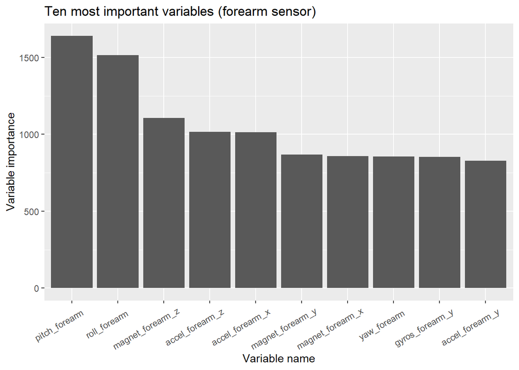

```r
#plot ten most important variables for the forearm sensor
p_forearm <- ggplot(vimp_forearm[1:10,], aes(x = reorder(names, -overall), y = overall)) +
         geom_bar(stat = "identity") + theme(axis.text.x=element_text(angle=30,vjust=.8, hjust=0.8)) + ggtitle("Ten most important variables (forearm sensor)") +
  xlab("Variable name") + ylab("Variable importance")
p_forearm
```

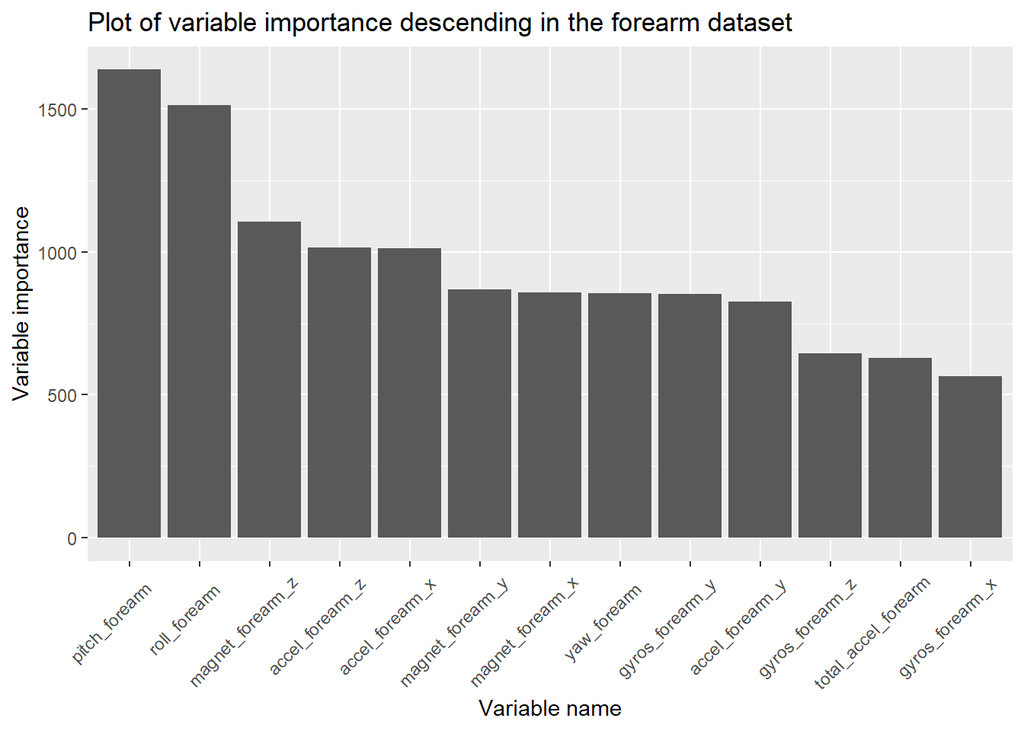

```r
#plot all the variables ordered by importance in the forearm dataset
p1_forearm <- ggplot(vimp_forearm, aes(x = reorder(names, -overall), y = overall)) +
         geom_bar(stat = "identity") + theme(axis.text.x=element_text(angle=45,vjust=.8, hjust=0.8)) + ggtitle("Plot of variable importance descending in the forearm dataset") +
  xlab("Variable name") + ylab("Variable importance")
p1_forearm
```

```r
#display the variable importance for the arm sensor
vimp_arm <- as.data.frame(varImp(rf_arm))
vimp_arm <- data.frame(names   = rownames(vimp_arm),overall = vimp_arm$Overall)
vimp_arm <- vimp_arm[order(vimp_arm$overall,decreasing = T),]
vimp_arm
```

```
##              names   overall
## 1         roll_arm 1355.8477
## 2        pitch_arm 1198.1216
## 12    magnet_arm_y 1054.1686
## 10     accel_arm_z 1021.0882
## 8      accel_arm_x 1019.3073
## 5      gyros_arm_x  974.2525
## 3          yaw_arm  954.1067
## 9      accel_arm_y  926.6895
## 13    magnet_arm_z  906.1745
## 11    magnet_arm_x  904.3207
## 6      gyros_arm_y  885.4024
## 7      gyros_arm_z  634.9076
## 4  total_accel_arm  571.2353
```

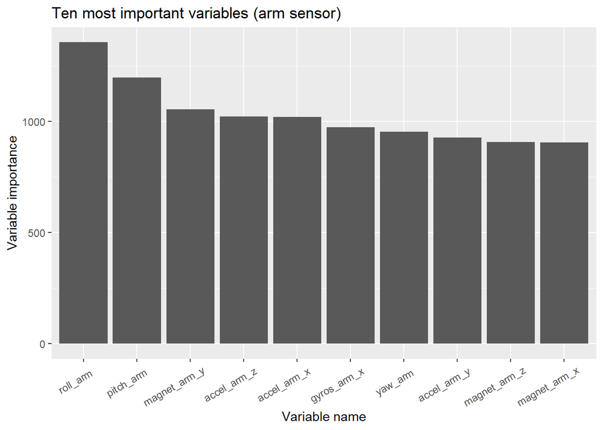

```r
#plot ten most important variables for the arm sensor
p_arm <- ggplot(vimp_arm[1:10,], aes(x = reorder(names, -overall), y = overall)) +
         geom_bar(stat = "identity") + theme(axis.text.x=element_text(angle=30,vjust=.8, hjust=0.8)) + ggtitle("Ten most important variables (arm sensor)") +
  xlab("Variable name") + ylab("Variable importance")
p_arm
```

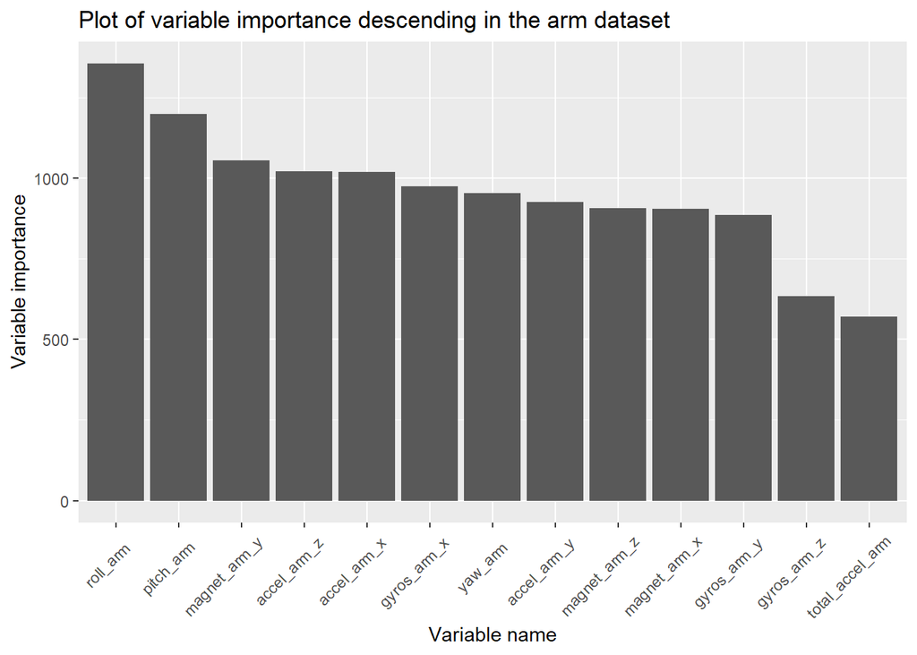

```r
#plot all the variables ordered by importance in the arm dataset
p1_arm <- ggplot(vimp_arm, aes(x = reorder(names, -overall), y = overall)) +
         geom_bar(stat = "identity") + theme(axis.text.x=element_text(angle=45,vjust=.8, hjust=0.8)) + ggtitle("Plot of variable importance descending in the arm dataset") +
  xlab("Variable name") + ylab("Variable importance")
p1_arm
```

```r
#display the variable importance for the belt sensor
vimp_belt <- as.data.frame(varImp(rf_belt))
vimp_belt <- data.frame(names   = rownames(vimp_belt),overall = vimp_belt$Overall)
vimp_belt <- vimp_belt[order(vimp_belt$overall,decreasing = T),]
vimp_belt
```

```
##               names   overall
## 3          yaw_belt 2152.6914
## 1         roll_belt 1953.4361
## 2        pitch_belt 1942.3692
## 13    magnet_belt_z  966.8088
## 11    magnet_belt_x  927.6861
## 10     accel_belt_z  891.8741
## 12    magnet_belt_y  763.2587
## 7      gyros_belt_z  679.3038
## 8      accel_belt_x  558.1784
## 5      gyros_belt_x  549.0709
## 9      accel_belt_y  382.7954
## 6      gyros_belt_y  327.0639
## 4  total_accel_belt  313.1955
```

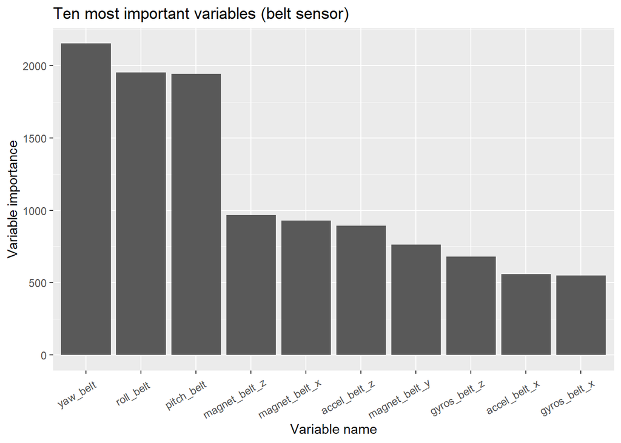

```r
#plot ten most important variables for the belt sensor
p_belt <- ggplot(vimp_belt[1:10,], aes(x = reorder(names, -overall), y = overall)) +
         geom_bar(stat = "identity") + theme(axis.text.x=element_text(angle=30,vjust=.8, hjust=0.8)) + ggtitle("Ten most important variables (belt sensor)") +
  xlab("Variable name") + ylab("Variable importance")
p_belt
```

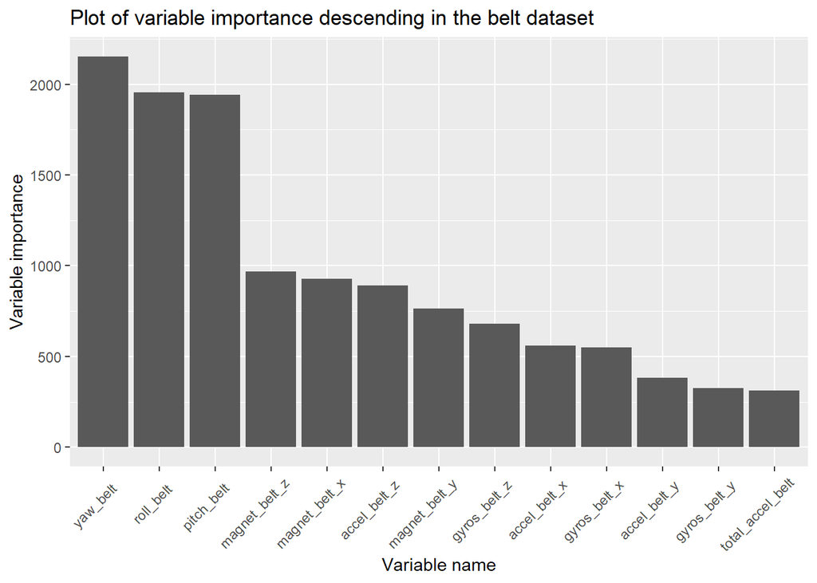

```r
#plot all the variables ordered by importance in the belt dataset
p1_belt <- ggplot(vimp_belt, aes(x = reorder(names, -overall), y = overall)) +
         geom_bar(stat = "identity") + theme(axis.text.x=element_text(angle=45,vjust=.8, hjust=0.8)) + ggtitle("Plot of variable importance descending in the belt dataset") +
  xlab("Variable name") + ylab("Variable importance")
p1_belt
```

```r
#display the variable importance for the dumbbell sensor
vimp_dumbbell <- as.data.frame(varImp(rf_dumbbell))
vimp_dumbbell <- data.frame(names   = rownames(vimp_dumbbell),overall = vimp_dumbbell$Overall)
vimp_dumbbell <- vimp_dumbbell[order(vimp_dumbbell$overall,decreasing = T),]
vimp_dumbbell
```

```
##                   names   overall
## 13    magnet_dumbbell_z 2014.0916
## 12    magnet_dumbbell_y 1431.3060
## 11    magnet_dumbbell_x 1234.3076
## 10     accel_dumbbell_z 1026.9153
## 9      accel_dumbbell_y  930.6558
## 1         roll_dumbbell  886.5468
## 6      gyros_dumbbell_y  863.5439
## 3          yaw_dumbbell  736.9701
## 4  total_accel_dumbbell  692.5466
## 5      gyros_dumbbell_x  690.9668
## 8      accel_dumbbell_x  651.1455
## 2        pitch_dumbbell  648.2099
## 7      gyros_dumbbell_z  561.5985
```

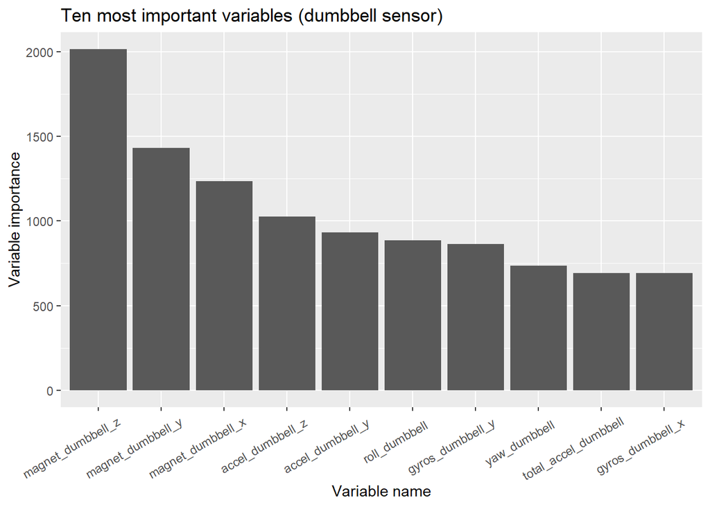

```r
#plot ten most important variables for the dumbbell sensor
p_dumbbell <- ggplot(vimp_dumbbell[1:10,], aes(x = reorder(names, -overall), y = overall)) +
         geom_bar(stat = "identity") + theme(axis.text.x=element_text(angle=30,vjust=.8, hjust=0.8)) + ggtitle("Ten most important variables (dumbbell sensor)") +
  xlab("Variable name") + ylab("Variable importance")
p_dumbbell
```

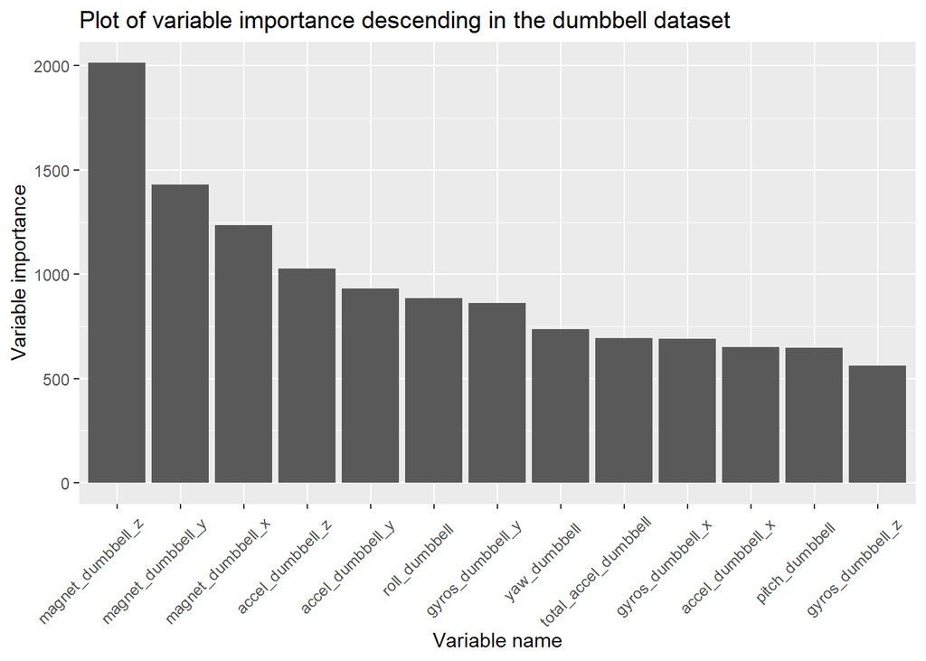

```r
#plot all the variables ordered by importance in the dumbbell dataset
p1_dumbbell <- ggplot(vimp_dumbbell, aes(x = reorder(names, -overall), y = overall)) +
         geom_bar(stat = "identity") + theme(axis.text.x=element_text(angle=45,vjust=.8, hjust=0.8)) + ggtitle("Plot of variable importance descending in the dumbbell dataset") +
  xlab("Variable name") + ylab("Variable importance")
p1_dumbbell
```

## Testing

```r
#test the model on the test dataset
pred_test <- predict(rf, test)
cm <- confusionMatrix(pred_test, test$classe)
cm
```

```
## Confusion Matrix and Statistics
##
##           Reference
## Prediction    A    B    C    D    E
##          A 1116    3    0    0    0
##          B    0  756    8    0    0
##          C    0    0  676    6    0
##          D    0    0    0  637    0
##          E    0    0    0    0  721
##
## Overall Statistics
##
##                Accuracy : 0.9957
##                  95% CI : (0.9931, 0.9975)
##     No Information Rate : 0.2845
##     P-Value [Acc > NIR] : < 2.2e-16
##
##                   Kappa : 0.9945
##  Mcnemar's Test P-Value : NA
##
## Statistics by Class:
##
##                      Class: A Class: B Class: C Class: D Class: E
## Sensitivity            1.0000   0.9960   0.9883   0.9907   1.0000
## Specificity            0.9989   0.9975   0.9981   1.0000   1.0000
## Pos Pred Value         0.9973   0.9895   0.9912   1.0000   1.0000
## Neg Pred Value         1.0000   0.9991   0.9975   0.9982   1.0000
## Prevalence             0.2845   0.1935   0.1744   0.1639   0.1838
## Detection Rate         0.2845   0.1927   0.1723   0.1624   0.1838
## Detection Prevalence   0.2852   0.1947   0.1738   0.1624   0.1838
## Balanced Accuracy      0.9995   0.9968   0.9932   0.9953   1.0000
```

We then tested the full prediction model on the full test dataset. The model predicted the value of dependent variable with very high accuracy of 0.9956666. The algorithm was able to classify almost all observations to the correct categories. The plot below demonstrates observations from the test dataset, correctly and incorrectly classified into categories.

```r
#test the model on the test datasets for each sensors
pred_test_forearm <- predict(rf_forearm, forearm_test)
cm_forearm <- confusionMatrix(pred_test_forearm, forearm_test$classe)
cm_forearm
```

```
## Confusion Matrix and Statistics
##
##           Reference
## Prediction    A    B    C    D    E
##          A 1081   46   12    4    2
##          B   14  672   63    6   25
##          C    5   10  566   39    7
##          D    5    8   19  581   17
##          E   11   23   24   13  670
##
## Overall Statistics
##
##                Accuracy : 0.91
##                  95% CI : (0.9006, 0.9188)
##     No Information Rate : 0.2845
##     P-Value [Acc > NIR] : < 2.2e-16
##
##                   Kappa : 0.886
##  Mcnemar's Test P-Value : 2.135e-13
##
## Statistics by Class:
##
##                      Class: A Class: B Class: C Class: D Class: E
## Sensitivity            0.9686   0.8854   0.8275   0.9036   0.9293
## Specificity            0.9772   0.9659   0.9812   0.9851   0.9778
## Pos Pred Value         0.9441   0.8615   0.9027   0.9222   0.9042
## Neg Pred Value         0.9874   0.9723   0.9642   0.9812   0.9840
## Prevalence             0.2845   0.1935   0.1744   0.1639   0.1838
## Detection Rate         0.2756   0.1713   0.1443   0.1481   0.1708
## Detection Prevalence   0.2919   0.1988   0.1598   0.1606   0.1889
## Balanced Accuracy      0.9729   0.9256   0.9043   0.9443   0.9535
```

```r
pred_test_arm <- predict(rf_arm, arm_test)
cm_arm <- confusionMatrix(pred_test_arm, arm_test$classe)
cm_arm
```

```
## Confusion Matrix and Statistics
##
##           Reference
## Prediction    A    B    C    D    E
##          A 1051   52   10   10    2
##          B   32  659   80    8   27
##          C   19   19  550   39    5
##          D    6   12   28  570   31
##          E    8   17   16   16  656
##
## Overall Statistics
##
##                Accuracy : 0.8886
##                  95% CI : (0.8783, 0.8983)
##     No Information Rate : 0.2845
##     P-Value [Acc > NIR] : < 2.2e-16
##
##                   Kappa : 0.859
##  Mcnemar's Test P-Value : 3.763e-10
##
## Statistics by Class:
##
##                      Class: A Class: B Class: C Class: D Class: E
## Sensitivity            0.9418   0.8682   0.8041   0.8865   0.9098
## Specificity            0.9736   0.9535   0.9747   0.9765   0.9822
## Pos Pred Value         0.9342   0.8176   0.8703   0.8810   0.9201
## Neg Pred Value         0.9768   0.9679   0.9593   0.9777   0.9798
## Prevalence             0.2845   0.1935   0.1744   0.1639   0.1838
## Detection Rate         0.2679   0.1680   0.1402   0.1453   0.1672
## Detection Prevalence   0.2868   0.2055   0.1611   0.1649   0.1817
## Balanced Accuracy      0.9577   0.9109   0.8894   0.9315   0.9460
```

```r
pred_test_belt <- predict(rf_belt, belt_test)
cm_belt <- confusionMatrix(pred_test_belt, belt_test$classe)
cm_belt
```

```
## Confusion Matrix and Statistics
##
##           Reference
## Prediction    A    B    C    D    E
##          A 1037   29   25   35   14
##          B   28  703   44    3    1
##          C   21   22  587   14    1
##          D   26    4   26  590    0
##          E    4    1    2    1  705
##
## Overall Statistics
##
##                Accuracy : 0.9233
##                  95% CI : (0.9145, 0.9314)
##     No Information Rate : 0.2845
##     P-Value [Acc > NIR] : < 2e-16
##
##                   Kappa : 0.9029
##  Mcnemar's Test P-Value : 0.03266
##
## Statistics by Class:
##
##                      Class: A Class: B Class: C Class: D Class: E
## Sensitivity            0.9292   0.9262   0.8582   0.9176   0.9778
## Specificity            0.9633   0.9760   0.9821   0.9829   0.9975
## Pos Pred Value         0.9096   0.9024   0.9101   0.9133   0.9888
## Neg Pred Value         0.9716   0.9822   0.9704   0.9838   0.9950
## Prevalence             0.2845   0.1935   0.1744   0.1639   0.1838
## Detection Rate         0.2643   0.1792   0.1496   0.1504   0.1797
## Detection Prevalence   0.2906   0.1986   0.1644   0.1647   0.1817
## Balanced Accuracy      0.9463   0.9511   0.9201   0.9503   0.9877
```

```r
pred_test_dumbbell <- predict(rf_dumbbell, dumbbell_test)
cm_dumbbell <- confusionMatrix(pred_test_dumbbell, dumbbell_test$classe)
cm_dumbbell
```

```
## Confusion Matrix and Statistics
##
##           Reference
## Prediction    A    B    C    D    E
##          A 1073   54   16   29    8
##          B    9  660   36    3   30
##          C   17   37  600   68   20
##          D   16    1   12  526   21
##          E    1    7   20   17  642
##
## Overall Statistics
##
##                Accuracy : 0.8924
##                  95% CI : (0.8823, 0.902)
##     No Information Rate : 0.2845
##     P-Value [Acc > NIR] : < 2.2e-16
##
##                   Kappa : 0.8636
##  Mcnemar's Test P-Value : 2.983e-16
##
## Statistics by Class:
##
##                      Class: A Class: B Class: C Class: D Class: E
## Sensitivity            0.9615   0.8696   0.8772   0.8180   0.8904
## Specificity            0.9619   0.9753   0.9562   0.9848   0.9859
## Pos Pred Value         0.9093   0.8943   0.8086   0.9132   0.9345
## Neg Pred Value         0.9843   0.9689   0.9736   0.9650   0.9756
## Prevalence             0.2845   0.1935   0.1744   0.1639   0.1838
## Detection Rate         0.2735   0.1682   0.1529   0.1341   0.1637
## Detection Prevalence   0.3008   0.1881   0.1891   0.1468   0.1751
## Balanced Accuracy      0.9617   0.9225   0.9167   0.9014   0.9382
```

We then tested all four algorithms associated with the separate sensors on the respective test datasets. The models predicted the values of the dependent variable with the accuracy of 0.923273 (belt), 0.9100178 (forearm), 0.8924293 (dumbbell) and 0.8886057 (arm).  
The algorithms were able to classify most observations to the correct categories. The plots below demonstrate observations from the general test dataset and four test datasets associated with single sensors, correctly and incorrectly classified into categories.

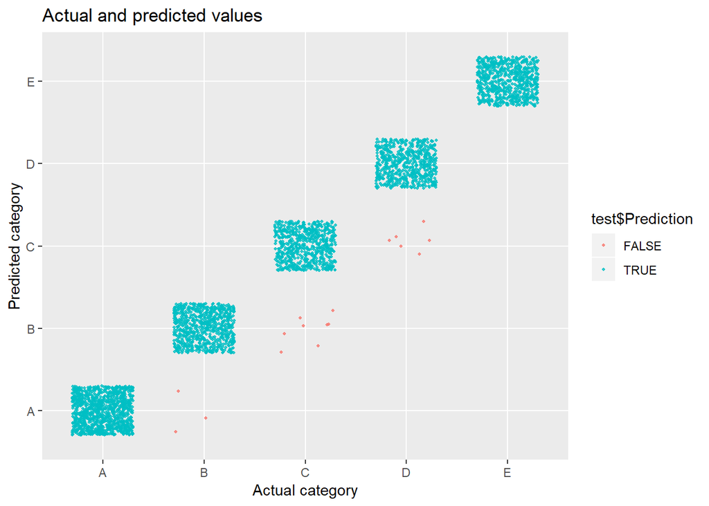

```r
#plot actual vs. predicted datapoints
test$Prediction <- pred_test==test$classe
accurate_pred_full <- test$Prediction
ggplot(aes(x=test$classe, y = pred_test,colour=test$Prediction), data = test) + geom_jitter(size=0.8,alpha=0.8,width = 0.3, height = 0.3) + ggtitle("Actual and predicted values") +
  xlab("Actual category") + ylab("Predicted category")
```

When all sensors were used for predictions, only few datapoints fell outside the correct categories. As we can see, the random forest algorithm correctly classified almost all observations.

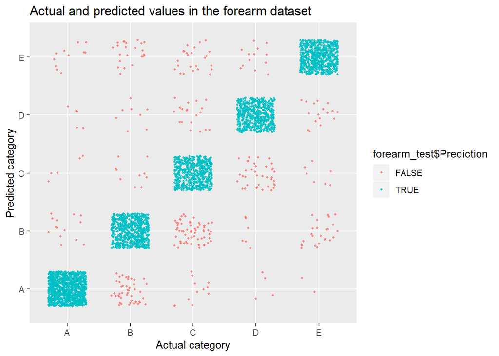

```r
#plot actual vs. predicted datapoints for the forearm dataset
forearm_test$Prediction <- pred_test_forearm==forearm_test$classe
accurate_pred_forearm <- forearm_test$Prediction
ggplot(aes(x=forearm_test$classe, y = pred_test_forearm,colour=forearm_test$Prediction), data = forearm_test) + geom_jitter(size=0.8,alpha=0.8,width = 0.3, height = 0.3) + ggtitle("Actual and predicted values in the forearm dataset") +
  xlab("Actual category") + ylab("Predicted category")
```

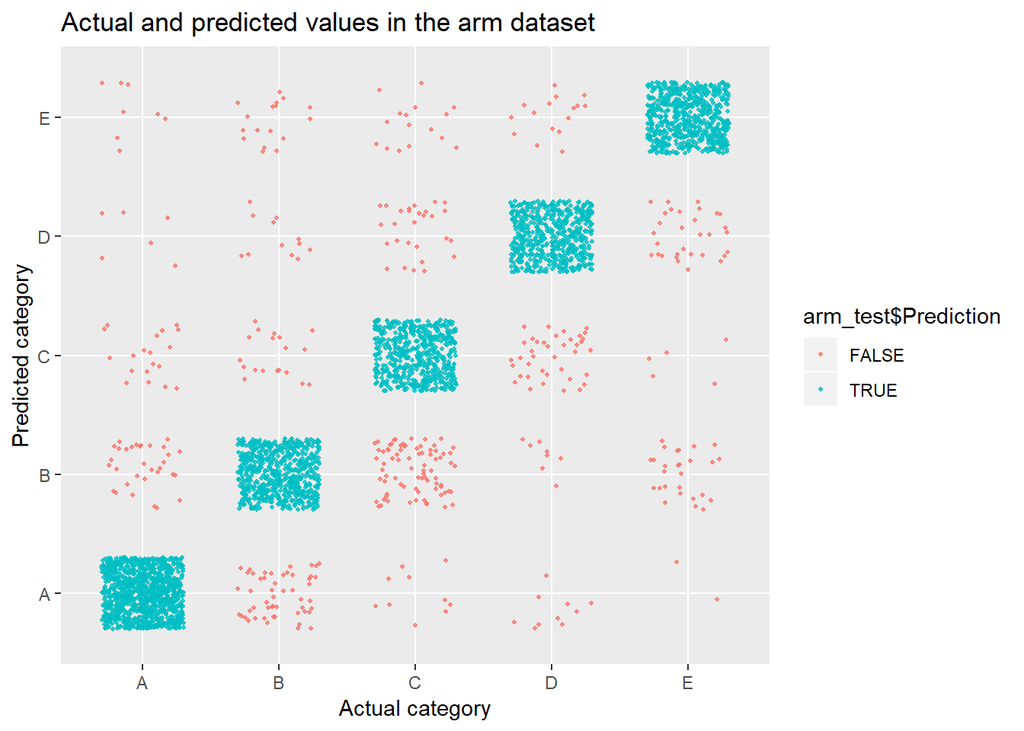

```r
#plot actual vs. predicted datapoints for the arm dataset
arm_test$Prediction <- pred_test_arm==arm_test$classe
accurate_pred_arm <- arm_test$Prediction
ggplot(aes(x=arm_test$classe, y = pred_test_arm,colour=arm_test$Prediction), data = arm_test) + geom_jitter(size=0.8,alpha=0.8,width = 0.3, height = 0.3) + ggtitle("Actual and predicted values in the arm dataset") +
  xlab("Actual category") + ylab("Predicted category")
```

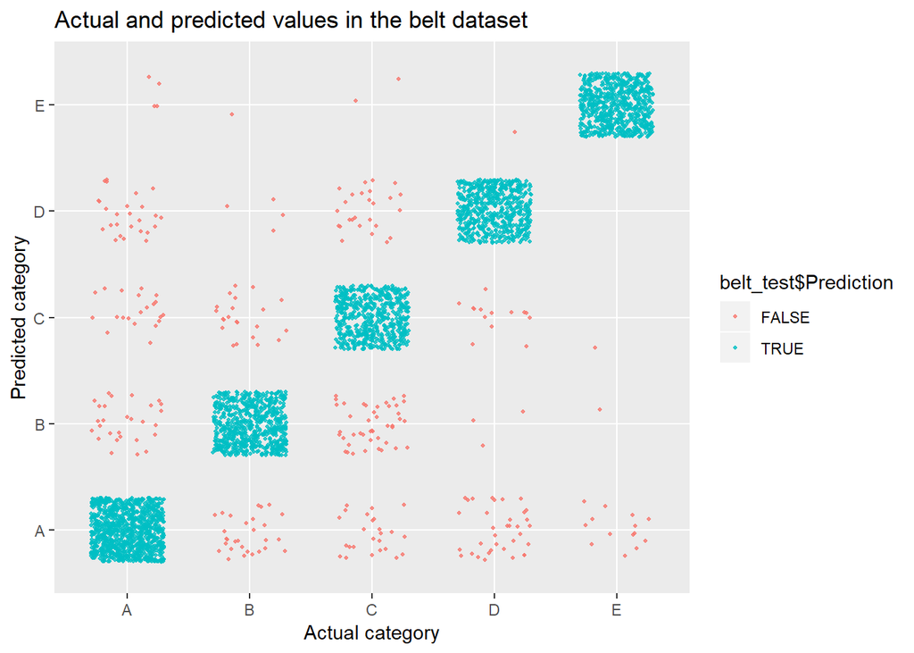

```r
#plot actual vs. predicted datapoints for the belt dataset
belt_test$Prediction <- pred_test_belt==belt_test$classe
accurate_pred_belt <- belt_test$Prediction
ggplot(aes(x=belt_test$classe, y = pred_test_belt,colour=belt_test$Prediction), data = belt_test) + geom_jitter(size=0.8,alpha=0.8,width = 0.3, height = 0.3) + ggtitle("Actual and predicted values in the belt dataset") +
  xlab("Actual category") + ylab("Predicted category")
```

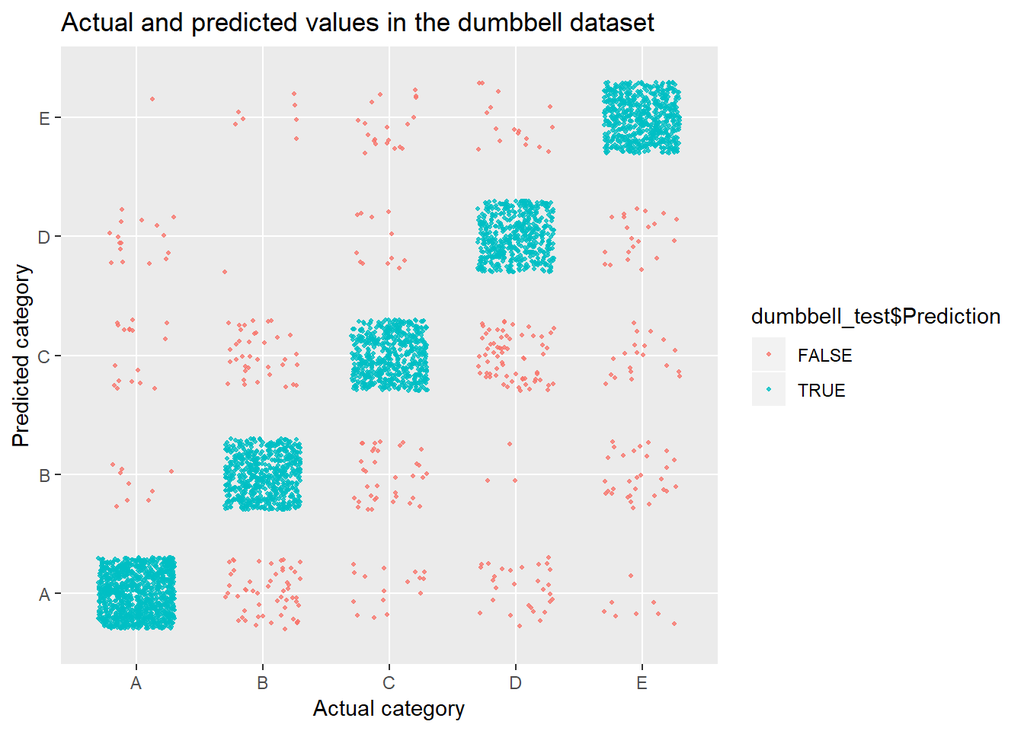

```r
#plot actual vs. predicted datapoints for the dumbbell dataset
dumbbell_test$Prediction <- pred_test_dumbbell==dumbbell_test$classe
accurate_pred_dumbbell <- dumbbell_test$Prediction
ggplot(aes(x=dumbbell_test$classe, y = pred_test_dumbbell,colour=dumbbell_test$Prediction), data = dumbbell_test) + geom_jitter(size=0.8,alpha=0.8,width = 0.3, height = 0.3) + ggtitle("Actual and predicted values in the dumbbell dataset") +
  xlab("Actual category") + ylab("Predicted category")
```

For separate sensors, most datapoints are correctly clasified, however a considerable number falls outside the correct categories.

Now we save test classes and predictions into a separate dataset to be used in a Shiny application.

```r
data_plot <- data.frame(testclass = test$classe, accurate_pred_full, pred_test_full = pred_test, accurate_pred_forearm, pred_test_forearm, accurate_pred_arm, pred_test_arm, accurate_pred_belt, pred_test_belt, accurate_pred_dumbbell, pred_test_dumbbell)

save(data_plot, file = "data_plot.RData")
```

## Summary

The random forest procedure performed on the readings from movement sensors allowed for very accurate classification of almost all observations in the test dataset into the correct categories.  
Limiting observations to single movement sensors reduces the accuracy of predictions. Among the sensors, the one placed on the athlete’s wrist corresponds to the way smartwatches / activity trackers are worn. The study demonstrates that a single sensor is still able to provide relatively high accuracy of predictions, however a potential automatic feedback feature might provide erroneous tips for the user.

## References

Velloso, E.; Bulling, A.; Gellersen, H.; Ugulino, W.; Fuks, H. Qualitative Activity Recognition of Weight Lifting Exercises. Proceedings of 4th International Conference in Cooperation with SIGCHI (Augmented Human ’13) . Stuttgart, Germany: ACM SIGCHI, 2013.